# Part II - Prosper Loan Characteristics on Loan Amounts

## Loan Amounts vs. Rates

> As loan amounts drop the rate percentages go up which aligns with a credit/loan issuing company. Prosper trusts the customer that obtains a higher riskier amount of a loan therefore they don't need to apply high APR or interest rates because they expect to be paid back in full and on time.

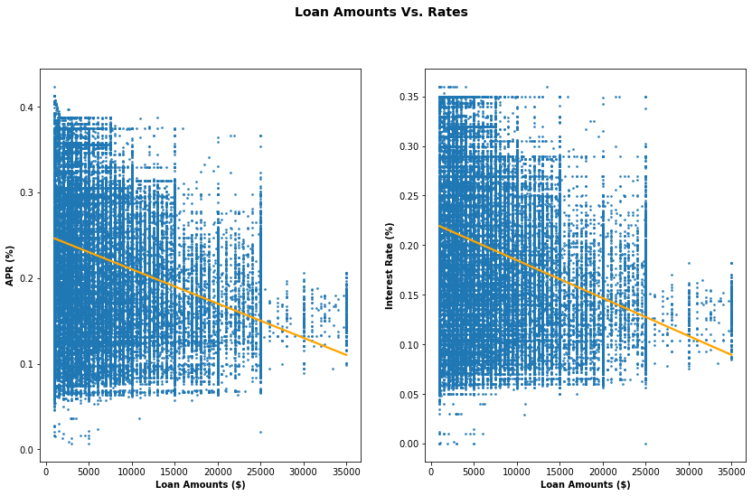

## BorrowerAPR vs. BorrowerRate

> As explained in the previous slide, we observe here the direct relationship between the rates, that is as APR goes up so does the interest rates for any loan.

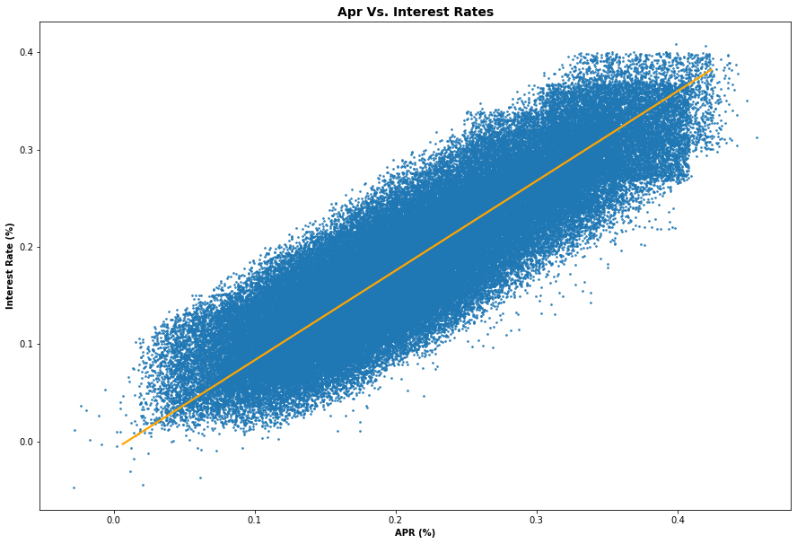

## Loan Amounts vs. Loan Status, Credit Grades, Prosper Ratings

> Higher credit grades and ratings are assigned to customers more often when they take higher loan amounts. Customers are more likely to complete or currently own a loan from Prosper if they were given a high loan amount.

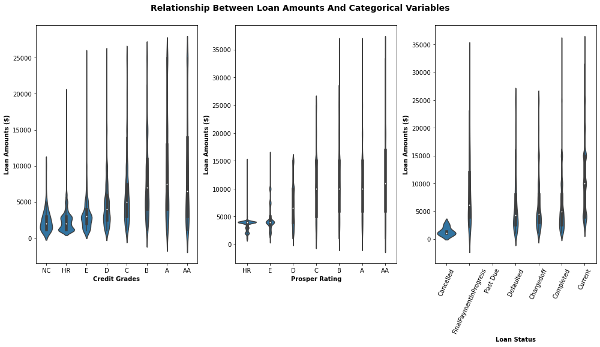